# Classification of five behaviors based on quantified self movement data

Yiyun

March 11, 2016

### Introduction

##### Using devices such as Jawbone Up, Nike FuelBand, and Fitbit it is now possible to collect a large amount of data about personal activity relatively inexpensively. These type of devices are part of the quantified self movement – a group of enthusiasts who take measurements about themselves regularly to improve their health, to find patterns in their behavior, or because they are tech geeks. One thing that people regularly do is quantify how much of a particular activity they do, but they rarely quantify how well they do it. In this project, the goal is to use data from accelerometers on the belt, forearm, arm, and dumbell of 6 participants. They were asked to perform barbell lifts correctly and incorrectly in 5 different ways. More information is available from the website here: http://groupware.les.inf.puc-rio.br/har (see the section on the Weight Lifting Exercise Dataset).

### Contents

#### 1. How to build the model

#### 2. How to use the cross-validation

#### 3. Estemated out of sample error

#### 4. Compare the prediction accuracy of different models

#### 5. Validation of the predicted results using test data

#### Initiliazation: update your variables here

```r
library(lattice)
library(ggplot2)
library(caret)
library(rpart)
library(rattle)
library(MASS)
library(mlbench)
library(class)
library(randomForest)
library(klaR)
Training_Link <- "https://d396qusza40orc.cloudfront.net/predmachlearn/pml-training.csv"
Test_Link <- "https://d396qusza40orc.cloudfront.net/predmachlearn/pml-testing.csv"
Traning_File_Name <- "pml-training.csv"
Test_File_Name <- "pml-testing.csv"
DataFolder <- "./Human Activity Project/" # folder where all your data are saved
```

#### Data Acquisition: all data are saved under the DataFolder

```r
if (!file.exists(DataFolder)) dir.create(DataFolder)
setwd(DataFolder)
if (!file.exists(Traning_File_Name)) download.file(url = Training_Link, destfile = paste(DataFolder, Traning_File_Name, sep = ""))
if (!file.exists(Test_File_Name)) download.file(url = Test_Link, destfile = paste(DataFolder, Test_File_Name, sep = ""))
Training_Data <- read.csv(file = Traning_File_Name)
Test_Data <- read.csv(file = Test_File_Name)
```

#### Preprocessing 1: remove non-features and transform data to numeric type

```r
Training_Data[, 7:159] <- sapply(Training_Data[, 7:159], as.numeric)
Test_Data[, 7:159] <- sapply(Test_Data[, 7:159], as.numeric)
Training_Data <- Training_Data[8:160]
Test_Data <- Test_Data[8:160]
```

#### Preprocessing 2: remove NA features

```r
nas <- is.na(apply(Test_Data,2,sum))
Test_Data <- Test_Data[,!nas]
dim(Test_Data)
```

```
## [1] 20 53
```

```r
Training_Data <- Training_Data[,!nas]
```

#### Create crossvalidation set in variable validation, the rest is training set in variable buildData

#### 70% of the training data will be used to train the model, 30% will be used for prediction and estimate

#### the out of sample error.

```r
inBuild <- createDataPartition(Training_Data$classe, p = 0.7, list = FALSE)
validation <- Training_Data[-inBuild[,1],]
buildData <- Training_Data[inBuild[,1],]
```

#### Rank feature importance and select important features for model training

#### In this case, there are less than 20 features

```r
model <- train(classe~., data = buildData, method = "rpart")
importance <- varImp(model, scale = FALSE)
print(importance, top = 15)
```

```
## rpart variable importance
##
##   only 15 most important variables shown (out of 52)
##
##                   Overall
## pitch_forearm      1480.1
## roll_forearm       1072.0
## roll_belt          1025.9
## magnet_dumbbell_y   732.6
## accel_belt_z        619.1
## magnet_belt_y       601.9
## yaw_belt            600.0
## total_accel_belt    512.5
## magnet_arm_x        390.5
## accel_arm_x         378.2
## roll_dumbbell       280.4
## magnet_dumbbell_x   268.9
## magnet_dumbbell_z   254.7
## accel_dumbbell_y    221.8
## roll_arm            219.7
```

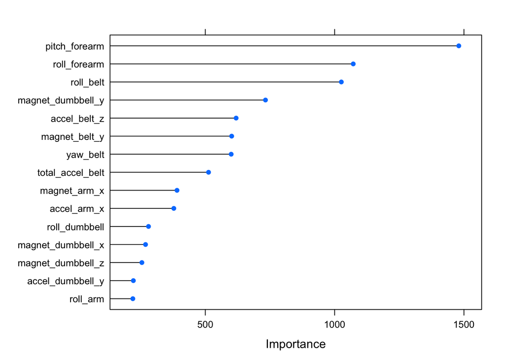

```r
plot(importance, top = 15)
```

```r
ImpVariables <- c("pitch_forearm",
                  "roll_forearm",
                  "roll_belt",
                  "magnet_dumbbell_y",
                  "accel_belt_z",
                  "magnet_belt_y",
                  "yaw_belt",
                  "magnet_dumbbell_z",
                  "total_accel_belt",
                  "magnet_arm_x",
                  "accel_arm_x",
                  "roll_dumbbell",
                  "accel_dumbbell_y",
                  "magnet_dumbbell_x",
                  "total_accel_dumbbell",
                  "pitch_belt",
                  "accel_dumbbell_x",
                  "accel_forearm_x")

important_features <- buildData[, colnames(buildData) %in% c(ImpVariables, "classe")]
validation_features <- validation[, colnames(validation) %in% c(ImpVariables, "classe")]
```

#### Use selected features to 1) train the the models and predict the outcome with validation dataset

#### Models used: 1) Recursive partitioning 2) linear discriminant analysis 3) random forest

1. Recursive partitioning

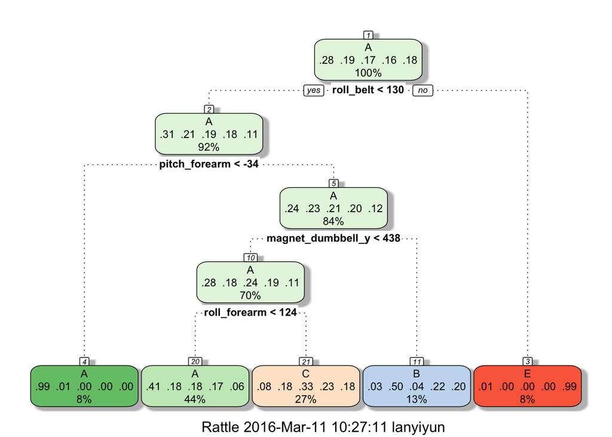

```r
modFit_rpart <- train(classe~., method = "rpart", data = important_features)
fancyRpartPlot(modFit_rpart$finalModel)
```

```r
pred_Rpart <- predict(modFit_rpart, validation_features)
Matrix_Rpart <- confusionMatrix(pred_Rpart, validation$classe)
```

2. linear discriminant analysis

```r
modFit_lda <- train(classe~., method = "lda", data = important_features, prox = TRUE)
pred_lda <- predict(modFit_lda, newdata = validation_features)
Matrix_lda <- confusionMatrix(pred_lda, validation$classe)
```

3. random forest

```r
modFit_rf <- train(classe~., method = "rf", data = important_features)
pred_rf <- predict(modFit_rf, newdata = validation_features)
Matrix_rf <- confusionMatrix(pred_rf, validation$classe)
```

#### Now we compare the prediction accuracy of out of sample errors among the 3 different models below.

#### It is clear that the random forest model has the lowest out of smaple errors and is selected as the

#### optimal model to predict the test dataset

1. Recursive partitioning

```r
Matrix_Rpart
```

```
## Confusion Matrix and Statistics
##
##           Reference
## Prediction    A    B    C    D    E
##          A 1530  483  493  431  154
##          B   27  388   38  173  139
##          C  115  268  495  360  294
##          D    0    0    0    0    0
##          E    2    0    0    0  495
##
## Overall Statistics
##
##                Accuracy : 0.4941
##                  95% CI : (0.4813, 0.507)
##     No Information Rate : 0.2845
##     P-Value [Acc > NIR] : < 2.2e-16
##
##                   Kappa : 0.3383
##  Mcnemar's Test P-Value : NA
##
## Statistics by Class:
##
##                      Class: A Class: B Class: C Class: D Class: E
## Sensitivity            0.9140  0.34065  0.48246   0.0000  0.45749
## Specificity            0.6293  0.92056  0.78658   1.0000  0.99958
## Pos Pred Value         0.4950  0.50719  0.32311      NaN  0.99598
## Neg Pred Value         0.9485  0.85332  0.87802   0.8362  0.89105
## Prevalence             0.2845  0.19354  0.17434   0.1638  0.18386
## Detection Rate         0.2600  0.06593  0.08411   0.0000  0.08411
## Detection Prevalence   0.5252  0.12999  0.26032   0.0000  0.08445
## Balanced Accuracy      0.7716  0.63061  0.63452   0.5000  0.72853
```

2. Linear discriminant analysis

```r
Matrix_lda
```

```
## Confusion Matrix and Statistics
##
##           Reference
## Prediction    A    B    C    D    E
##          A 1226  287  279  114  130
##          B   63  456   73   56  146
##          C   91  194  584   78  145
##          D  267  169   79  648  138
##          E   27   33   11   68  523
##
## Overall Statistics
##
##                Accuracy : 0.584
##                  95% CI : (0.5713, 0.5967)
##     No Information Rate : 0.2845
##     P-Value [Acc > NIR] : < 2.2e-16
##
##                   Kappa : 0.4709
##  Mcnemar's Test P-Value : < 2.2e-16
##
## Statistics by Class:
##
##                      Class: A Class: B Class: C Class: D Class: E
## Sensitivity            0.7324  0.40035  0.56920   0.6722  0.48336
## Specificity            0.8076  0.92878  0.89545   0.8673  0.97106
## Pos Pred Value         0.6022  0.57431  0.53480   0.4981  0.79003
## Neg Pred Value         0.8836  0.86584  0.90778   0.9311  0.89297
## Prevalence             0.2845  0.19354  0.17434   0.1638  0.18386
## Detection Rate         0.2083  0.07749  0.09924   0.1101  0.08887
## Detection Prevalence   0.3460  0.13492  0.18556   0.2211  0.11249
## Balanced Accuracy      0.7700  0.66457  0.73233   0.7698  0.72721
```

3. random forest

```r
Matrix_rf
```

```
## Confusion Matrix and Statistics
##
##           Reference
## Prediction    A    B    C    D    E
##          A 1673   14    0    0    0
##          B    1 1120    8    0    0
##          C    0    5 1018    9    0
##          D    0    0    0  955    9
##          E    0    0    0    0 1073
##
## Overall Statistics
##
##                Accuracy : 0.9922
##                  95% CI : (0.9896, 0.9943)
##     No Information Rate : 0.2845
##     P-Value [Acc > NIR] : < 2.2e-16
##
##                   Kappa : 0.9901
##  Mcnemar's Test P-Value : NA
##
## Statistics by Class:
##
##                      Class: A Class: B Class: C Class: D Class: E
## Sensitivity            0.9994   0.9833   0.9922   0.9907   0.9917
## Specificity            0.9967   0.9981   0.9971   0.9982   1.0000
## Pos Pred Value         0.9917   0.9920   0.9864   0.9907   1.0000
## Neg Pred Value         0.9998   0.9960   0.9984   0.9982   0.9981
## Prevalence             0.2845   0.1935   0.1743   0.1638   0.1839
## Detection Rate         0.2843   0.1903   0.1730   0.1623   0.1823
## Detection Prevalence   0.2867   0.1918   0.1754   0.1638   0.1823
## Balanced Accuracy      0.9980   0.9907   0.9947   0.9944   0.9958
```

#### Prediction outcome using the test dataset

```r
predict(modFit_rf, newdata = Test_Data)
```

```
##  [1] B A B A A E D B A A B C B A E E A B B B
## Levels: A B C D E
```